# intro

21007

2021/12/16

## Overview

**StatComp21007** is a simple R package including all homework and two SCAD functions. *SCAD_cv* uses cross-validation method to select the penalty coefficient $\lambda$ for SCAD penalty function. *SCAD_Function* is used for variable selection and parameter determination. Both functions are for classical linear model.

These algorithms and theories come from $Fan & Li: Nonconcave Penalized Likelihood$.

## Algorithm

**Cross-Validation**

In *SCAD_cv* , we use leave-one-out cross-validation.

Cross-Validation score can be expressed as
$$CV = \frac{1}{n}\sum_{i=1}^{n}(\frac{y-\hat{y}_i}{1-H_{ii}})^2$$

Where $H=X(X^TX)^{-1}X^T$, $\hat{y}_i$ is the predicted value of the model based on the whole data.

**SCAD iterative process**

The objective function is as follows:
$$\frac{1}{2}(y-X\beta)'(y-X\beta)+n\sum_{j=1}^{d}p_{\lambda}(|\beta_j|)$$
Where
$$p_{\lambda}'(\theta)=\lambda(I(\theta \le \lambda)+\frac{(a\lambda-\theta)_+}{(a-1)\lambda}I(\theta>\lambda)) , a>0 , \lambda>0$$
Iterative process:

$${\beta_j}^{(k)}={\beta_j}^{(k-1)}-[\frac{\partial ^2l(\beta)}{\partial{\beta_j}^2}]^{-1}\frac{\partial l(\beta)}{\partial \beta_j}$$
*SCAD_cv*

```r
SCAD_cv <- function(X, y, A) {

  #to define SCAD penalty derivative
  pen_der<-function(theta,a = 3.7,lambda){
    if(abs(theta) > lambda){
      if(a * lambda > theta){
        return((a * lambda - theta)/(a - 1))
      }else{
        return(0)
      }
    }else{
      return(lambda)
    }
  }

  #Initialization coefficient
  b_ls <- stats::lm(y~X)$coefficients
  #the maximum iterations
  max_iteration<-1e4
  #A column 1 is added before X to facilitate the processing of intercept items
  inter_y <- matrix(1,nrow = length(y),ncol = 1)
  X <- cbind(inter_y,X)

  H <- X %*% solve(t(X) %*% X) %*% t(X)
  CV_score <- rep(0,length(A))

  for(i in 1:length(A)){
  b0 <- b_ls
  ll <- A[i]
  iteration<-0
  while(iteration < max_iteration){
    for(j in 1:length(b0)){
      if(abs(b0[j]) < 1e-06){
        next()
      }else{
        nominator<-sum(- X[,j] * (y - X %*% b0)) + nrow(X)*b0[j]*pen_der(theta = b0[j],lambda =ll)/abs(b0[j])
        denominator<- sum(X[,j]^2) + nrow(X)*pen_der(theta = b0[j],lambda =ll)/abs(b0[j])
        b0[j]<-b0[j] - nominator/denominator
        if(abs(b0[j]) < 1e-06){
          b0[j] <- 0
        }
      }
    }
    iteration <- iteration+1
  }

  y_hat <- X %*% b0
  s = 0
  for(k in 1:length(y)){
    s = s + ((y[k]-y_hat[k])/(1-H[k,k]))^2
  }
  CV_score[i] <- s/length(y)
  }

  for(i in 1:length(A)){
    if(CV_score[length(A)-i+1] < 1){
      index=(length(A)-i+1)
      break
    }
  }
  return( A[index])
}
```

*SCAD_Function*

```r
SCAD_Function <- function(X, y) {

  #to find the best lambda by cv
  b0<- stats::lm(y~X)$coefficients
  qq <- max(abs(b0))
  if(qq > 50){
    A <- seq(0,qq,1)
  }else{
    A <- seq(0,qq,0.1)
  }
  cv_lambda <- SCAD_cv(X,y,A)

  #to define SCAD penalty
  pen_fun<-function(theta,lambda = cv_lambda){
    p_lambda<-sapply(theta, function(x){
      if(abs(x)< lambda){
        return(lambda^2 - (abs(x) - lambda)^2)
      }else{
        return(lambda^2)
      }
    }
    )
    return(p_lambda)
  }

  #to define SCAD penalty derivative
  pen_der<-function(theta,a = 3.7,lambda = cv_lambda){
    if(abs(theta) > lambda){
      if(a * lambda > theta){
        return((a * lambda - theta)/(a - 1))
      }else{
        return(0)
      }
    }else{
      return(lambda)
    }
  }

  #Initialization coefficient
  b0<- stats::lm(y~X)$coefficients
  #Iteration counter
  iteration<-0
  #the maximum iterations
  max_iteration<-100000
  #A column 1 is added before X to facilitate the processing of intercept items
  inter_y <- matrix(1,nrow = length(y),ncol = 1)
  X <- cbind(inter_y,X)

  #SCAD iterative process
  while(iteration < max_iteration){
    for(j in 1:length(b0)){
      if(abs(b0[j]) < 1e-06){
        next()
      }else{
        #nominator
        nominator<-sum(- X[,j] * (y - X %*% b0)) + nrow(X)*b0[j]*pen_der(theta = b0[j])/abs(b0[j])
        #denominator__the second derivative
        denominator<- sum(X[,j]^2) + nrow(X)*pen_der(theta = b0[j])/abs(b0[j])
        #Iterate b0[j]
        b0[j]<-b0[j] - nominator/denominator
        #If b0[j] is small, make it equal to 0.
        if(abs(b0[j]) < 1e-06){
          b0[j] <- 0
        }
      }
    }
    iteration <- iteration+1
  }
  return(b0)
}
```

```r
library(MASS)
library(ncvreg)
library(stats)

Simu_Multi_Norm<-function(x_len, sd = 1, pho = 0.5){
  V <- matrix(data = NA, nrow = x_len, ncol = x_len)
  for(i in 1:x_len){
    for(j in 1:x_len){
      V[i,j] <- pho^abs(i-j)
    }
  }
  V<-(sd^2) * V
  return(V)
}

set.seed(123)
X<-mvrnorm(n = 60, mu = rep(0,8), Simu_Multi_Norm(x_len = 8,sd  = 1, pho = 0.5))
beta<-c(1,0.5,0.02,0,2,0,10,0.05)
y<- X %*% beta + rnorm(n = 60, 0, 1)

A <- seq(0,2,0.1)
SCAD_cv(X,y,A)
```

```
## [1] 0.2
```

```r
B <- cv.ncvreg(X,y,penalty='SCAD')
B$lambda.min
```

```
## [1] 0.1274401
```

```r
SCAD_Function(X,y)
```

```
## (Intercept)          X1          X2          X3          X4          X5
##   0.0000000   0.9273742   0.3897171   0.0000000   0.0000000   2.0029358
##          X6          X7          X8
##   0.0000000   9.9797247   0.0000000
```

## Homework0

Use knitr to produce at least 3 examples (texts, figures, tables).

1.texts: Statistical calculation is an interdisciplinary subject of mathematical statistics, computational mathematics and computer science. This is the first job of statistical calculation.

2.Mathematical formula: $e^{i\theta}=\cos\theta+i\sin\theta$

3.figures:

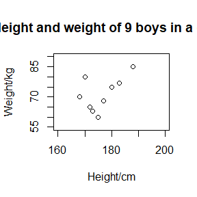

```r
A<-c(172,170,180,175,188,168,177,183,173)
B<-c(65,80,75,60,85,70,68,77,63)
plot(A,B,xlab="Height/cm",ylab="Weight/kg",xlim=c(160,200),ylim=c(55,90),main="Height and weight of 9 boys in a class")
```

4.tables:

```r
a<-matrix(runif(15),5,3)
dimnames(a)<-list(NULL,c("Group one","Group two","Group three"))
knitr::kable(head(a))
```

| Group one | Group two | Group three |
| --- | --- | --- |
| 0.2073655 | 0.6909898 | 0.4018139 |
| 0.4592408 | 0.2869576 | 0.6485563 |
| 0.2415023 | 0.1494125 | 0.9163057 |
| 0.1186903 | 0.9724320 | 0.2166621 |
| 0.0724691 | 0.4105144 | 0.5479989 |

## Homework1

Exercises 3.4, 3.11, and 3.20 (pages 94-96, Statistical Computating with R).

**3.4**

Firstly, we integrate the probability density function to obtain the probability distribution function
$$F(x)=1-e^{-x^2/(2σ^2)} , x≥0 , σ>0$$
Because $X$ is a continuous random variable, $F(X)$ is a uniform distribution $U(0,1)$.We can get
$$X=\sqrt{(-2σ^2\ln(1-U))}$$
Finally, we use the inverse transform method to solve this problem.

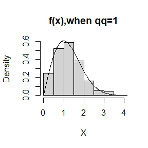

```r
n <- 1000; qq <- 1
X <- sqrt(-2*(qq^2)*log(1-runif(n)))
hist(X, prob = TRUE, main = "f(x),when qq=1")
Y <- seq( 0, 5, .01)
lines(Y, (Y/(qq^2))*exp(-(Y^2)/(2*qq^2)))
```

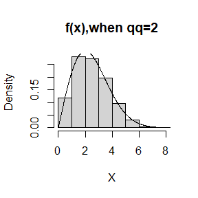

```r
n <- 1000; qq <- 2
X <- sqrt(-2*(qq^2)*log(1-runif(n)))
hist(X, prob = TRUE, main = "f(x),when qq=2")
Y <- seq( 0, 10, .01)
lines(Y, (Y/(qq^2))*exp(-(Y^2)/(2*qq^2)))
```

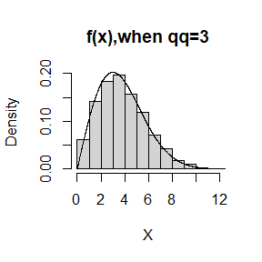

```r
n <- 1000; qq=3
X <- sqrt(-2*(qq^2)*log(1-runif(n)))
hist(X, prob = TRUE, main = "f(x),when qq=3")
Y <- seq( 0, 15, .01)
lines(Y, (Y/(qq^2))*exp(-(Y^2)/(2*qq^2)))
```

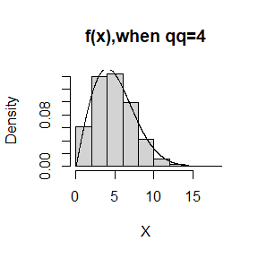

```r
n <- 1000; qq=4
X <- sqrt(-2*(qq^2)*log(1-runif(n)))
hist(X, prob = TRUE, main = "f(x),when qq=4")
Y <- seq( 0, 20, .01)
lines(Y, (Y/(qq^2))*exp(-(Y^2)/(2*qq^2)))
```

As we can be seen from the figures, when $σ$ takes different values, the modes of the generated samples are all very close to the theoretical modes.

**3.11**

Firstly, we generate 1000 random numbers subject to $N(0,1)$ and $N(3,1)$ distributions.Then, we combine the two groups of random numbers in terms of the mixing probability.

Let $P_1$ take $0.75$, we can get the following figure.

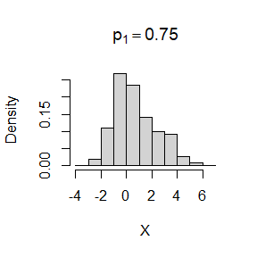

Repeat with different values for $p_1$ and observe whether the empirical distribution of the mixture appears to be bimodal.

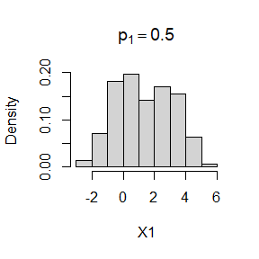

```r
n <- 1000 ;
Z1 <- rnorm(n,0,1)
Z2 <- rnorm(n,3,1)

A1 <- runif(n)
k1 <- as.integer(A1 < 0.5)
X1 <- k1 * Z1 + (1-k1) * Z2

A2 <- runif(n)
k2 <- as.integer(A2 < 0.25)
X2 <- k2 * Z1 + (1-k2) * Z2

A3 <- runif(n)
k3 <- as.integer(A3 < 0.9)
X3 <- k3 * Z1 + (1-k3) * Z2

A4 <- runif(n)
k4 <- as.integer(A4 < 0.1)
X4 <- k4 * Z1 + (1-k4) * Z2


hist(X1, prob = TRUE, main=expression(p[1]==0.5))
```

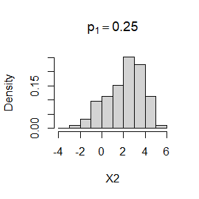

```r
hist(X2, prob = TRUE, main=expression(p[1]==0.25))
```

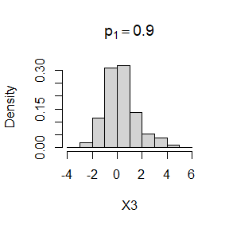

```r
hist(X3, prob = TRUE, main=expression(p[1]==0.9))
```

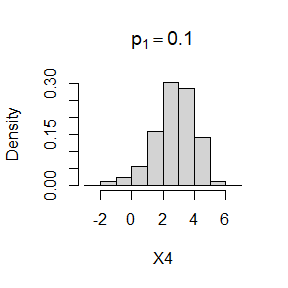

```r
hist(X4, prob = TRUE, main=expression(p[1]==0.1))
```

By observing the figures generated by different $p_1$, we can find that the closer $p_1$ is to $0.5$, the more obvious the bimodal mixtures are.

**3.20**

Firstly, we need to take a sample $N(t)$ from the Poisson($\lambda$) process. Then, we take $N(t)$ samples from the gamma distribution $Gamma(r,\beta)$ and add the values of these samples together.Repeat the above process $n$ times.

According to the hint, we can know
$$E(X(t))=\lambda tE(Y_1)=\lambda t \frac{r}{\beta}$$
$$Var(X(t))=\lambda tE(Y_1^2)=\lambda t \frac{r(r+1)}{\beta^2}$$
In the end, estimate the mean and the variance of $X(10)$ for several choices of the parameters and compare with the theoretical values.

When $\lambda=2,r=3,\beta=4$,
$$E(X(t))=15,Var(X(t))=15$$
The mean and variance of the sample are as follows:

```
## [1] 15.05052
```

```
## [1] 14.39862
```

When $\lambda=5,r=6,\beta=10$
$$E(X(t))=30,Var(X(t))=21$$
The mean and variance of the sample are as follows:

```
## [1] 30.13905
```

```
## [1] 20.34982
```

As we can see, the estimates of the mean and variance are very close to the theoretical values.

## Homework2

Exercises 5.4, 5.9, 5.13, and 5.14 (pages 149-151, Statistical Computating with R).

**5.4**

The Cumulative distribution function (CDF) of Beta(3,3) is
$$F(x)=\int_{0}^{x}\frac{1}{B(3,3)}x^2(1-x)^2\,dx , 0\le x\le 1$$
Where,
$$B(3,3)=\int_{0}^{1}x^2(1-x)^2\,dx=\frac{1}{30}$$
Compare the Monte Carlo estimates with the values returned by the pbeta function for x=0.1,0.2, … ,0.9.

```r
n <- 1000;

f <- function(x)
{
  a <- runif(n, min=0, max=x);
  b <- mean(a^2*(1-a)^2)*x
  return(b)
}

c <- numeric(9)
d <- numeric(9)

for(i in 1:9)
{
  c[i]=f(i/10)*30
  d[i]=pbeta(i/10,3,3)
}

e <-c((1:9)/10)
p <- rbind(e,c,d)
rownames(p) <- c("x","estimates","pbeta")
knitr::kable(head(p))
```

| x | 0.1000000 | 0.2000000 | 0.3000000 | 0.4000000 | 0.500000 | 0.6000000 | 0.7000000 | 0.8000000 | 0.900000 |
| --- | --- | --- | --- | --- | --- | --- | --- | --- | --- |
| estimates | 0.0083977 | 0.0579704 | 0.1646767 | 0.3088176 | 0.488525 | 0.6943345 | 0.8586401 | 0.9613226 | 1.030116 |
| pbeta | 0.0085600 | 0.0579200 | 0.1630800 | 0.3174400 | 0.500000 | 0.6825600 | 0.8369200 | 0.9420800 | 0.991440 |

As we can see, the estimates are very close to the values returned by the pbeta function.

**5.9**

Firstly, we integrate the probability density function to obtain the probability distribution function
$$F(x)=1-e^{-x^2/(2σ^2)} , x≥0 , σ>0$$
Because $X$ is a continuous random variable, $F(X)$ is a uniform distribution $U(0,1)$.We can get
$$X=\sqrt{(-2σ^2\ln(1-U))}$$

The antithetic variable is
$$X'=\sqrt{(-2σ^2\ln(U))}$$

We take different values for $\sigma$ to calculate the percent reduction in variance.

```r
rf <- function(sigma)
{
  n <- 1000;
  a <- runif(n/2)
  b <- runif(n/2)
  X <- sqrt(-2*(sigma^2)*log(1-a))
  X_anti <- sqrt(-2*(sigma^2)*log(a))

  X1 <- sqrt(-2*(sigma^2)*log(1-a))
  X2 <- sqrt(-2*(sigma^2)*log(1-b))

  e <- var((X+X_anti)/2)
  f <- var((X1+X2)/2)

  return((f-e)/f)
}

g <- c(1:10)
h <- numeric(10)
for(i in 1:10)
  h[i] <- rf(i)

k <- rbind(g,h)
k <- round(k,3)
rownames(k) <- c("σ","reduction in var")
knitr::kable(head(k))
```

| σ | 1.000 | 2.000 | 3.000 | 4.000 | 5.000 | 6.00 | 7.000 | 8.000 | 9.000 | 10.000 |
| --- | --- | --- | --- | --- | --- | --- | --- | --- | --- | --- |
| reduction in var | 0.958 | 0.928 | 0.943 | 0.945 | 0.956 | 0.94 | 0.953 | 0.953 | 0.947 | 0.953 |

As we can see, no matter what the value of $sigma$ is, the percent reduction in variance of $\frac{X+X'}{2}$ compared with $\frac{X_1+X_2}{2}$ for independent $X_1$, $X_2$ are all very close to $94.7\%$.

**5.13**

We can find two importance functions
$$f_1=e^{-x},x>1$$
$$f_2=\frac{1}{\sqrt{2\pi}}e^{-\frac{(x-1.65)^2}{2}},x>1$$

```r
n <- 1000
theta.hat <- se <- numeric(2)
g <- function(x)
{
  x^2*exp(-x^2/2)/sqrt(2*pi) * (x>1)
}

x <- rexp(n,1)    #using f1
fg <- g(x)/exp(-x)
theta.hat[1] <- mean(fg)
se[1] <- sd(fg)

x <- rnorm(n,1.65,1)   #using f2
fg <- g(x)/(exp(-(x-1.65)^2/2)/sqrt(2*pi))
theta.hat[2] <- mean(fg)
se[2] <- sd(fg)

c <- rbind(theta.hat,se)
colnames(c) <- paste0('f',1:2)
knitr::kable(c)
```

|  | f1 | f2 |
| --- | --- | --- |
| theta.hat | 0.3797122 | 0.3788629 |
| se | 0.5729378 | 0.2955832 |

As we can see,
$$f_2=\frac{1}{\sqrt{2\pi}}e^{-\frac{(x-1.65)^2}{2}},x>1$$
produce the smaller variance in estimating
$$\int_{1}^{\infty}\frac{x^2}{\sqrt{2\pi}}e^{-x^2/2}\,dx$$

**5.14**

From 5.13, we can know that
$$f_2=\frac{1}{\sqrt{2\pi}}e^{-\frac{(x-1.65)^2}{2}},x>1$$
is an importance function with smaller variance.So we use $f_2$ to estimate
$$\int_{1}^{\infty}\frac{x^2}{\sqrt{2\pi}}e^{-x^2/2}\,dx$$

```r
n <- 1000
g <- function(x)
{
  x^2*exp(-x^2/2)/sqrt(2*pi) * (x>1)
}

x <- rnorm(n,1.65,1)   #using f2
fg <- g(x)/(exp(-(x-1.65)^2/2)/sqrt(2*pi))
mean(fg)
```

```
## [1] 0.40521
```

As we can see, the Monte Carlo estimate of
$$\int_{1}^{\infty}\frac{x^2}{\sqrt{2\pi}}e^{-x^2/2}\,dx$$
by importance sampling is close to $0.4$.

## Homework3

Exercises 6.5 and 6.A (page 180-181, Statistical Computating with R).

If we obtain the powers for two methods under a particular simulation setting with 10,000 experiments: say, 0.651 for one method and 0.676 for another method. We want to know if the powers are different at 0.05 level.

(1)What is the corresponding hypothesis test problem?

(2)What test should we use? Z-test, two-sample t-test, paired-t test or McNemar test? Why?

(3)Please provide the least necessary information for hypothesis testing.

**6.5**

As we all know,
$$\frac{\bar{x}-u}{S}\sqrt{n}\sim t(n-1)$$
So the $1-\alpha$ confidence interval of the mean is
$$(\bar{x}-\frac{t_{\frac{\alpha}{2}}(n-1)S}{\sqrt{n}},\bar{x}+\frac{t_{\frac{\alpha}{2}}(n-1)S}{\sqrt{n}})$$
The coverage probability can be approximated by
$$\frac{1}{m} \sum\limits_{j=1}^mI(\hat{\theta}_1^{(j)}<\theta<\hat{\theta}_2^{(j)})$$
Where $(\hat{\theta}_1^{(j)},\hat{\theta}_2^{(j)})$ is the CI of $\theta$ in the $j$th MC experiment.

We take random samples of $\chi^2(2)$ data with sample size $n=20$.

```r
set.seed(1000)
n <- 20;alpha <- 0.05
a <- numeric(1000) ;b <- numeric(1000)
for(i in 1:1000)
{
  x <- rchisq(n,df=2)
  a[i] <- mean(x)-qt(alpha/2,df=n-1)*sqrt(var(x))/sqrt(n)
  b[i] <- mean(x)+qt(alpha/2,df=n-1)*sqrt(var(x))/sqrt(n)
}

mean( a>2 & b<2 )
```

```
## [1] 0.932
```

The estimate of the CP of the t-interval is around $0.93$, which is smaller than $0.95$.

Compared with Example 6.4, the t-interval is more robust to departures from normality than the interval for variance.

**6.A**

It is calculated that the mean of $\chi^2(1)$, $Uniform(0,2)$ and $Exponential(1)$ are the same:
$$u_0=1$$

```r
set.seed(10000)
n <- 20;alpha <- 0.05;u=1

a <- numeric(100) ;b <- numeric(100) ;c <- numeric(100)

for(i in 1:100)
{
  x <- rchisq(n,df=1)
  ttest1 <- t.test(x, mu=u)
  a[i] <- ttest1$p.value

  y <- runif(n,0,2)
  ttest2 <- t.test(y,alternative = "two.sided", mu=u)
  b[i] <- ttest2$p.value

  z <- rexp(n,1)
  ttest3 <- t.test(z,mu=u)
  c[i] <- ttest3$p.value
}

d <- e <- numeric(3)
d[1] <- mean(a<alpha)
d[2] <- mean(b<alpha)
d[3] <- mean(c<alpha)

e[1] <- sqrt(d[1]*(1-d[1])/100)
e[2] <- sqrt(d[2]*(1-d[2])/100)
e[3] <- sqrt(d[3]*(1-d[3])/100)

p<- rbind(d,e)
rownames(p) <- c("alpha.hat","se.hat")
colnames(p) <- c("卡方(1)","Uniform(0,2)","Exponential(1)")
knitr::kable(p)
```

|  | 卡方(1) | Uniform(0,2) | Exponential(1) |
| --- | --- | --- | --- |
| alpha.hat | 0.0500000 | 0.0300000 | 0.0700000 |
| se.hat | 0.0217945 | 0.0170587 | 0.0255147 |

As we can see, the t-test is robust to mild departures from normality.

**3**

3.1
$$H_0: power_1=power_2\quad (The\ powers\ are\ the\ same\ at\ 0.05\ level.)$$
$$H_1: power_1\neq power_2\quad (The\ powers\ are\ different\ at\ 0.05\ level.)$$
Where $power_1$ and $power_2$ stand for the powers for two methods under a particular simulation setting with 10,000 experiments.

3.2

I think paired-t test is the best choice.

As for two-sample t-test, it requires two sets of samples to be independent, but this subject does not meet this condition. As for Z-test and McNemar test, they are better for large samples.

3.3

We should know the following four messages:

$n$:The number of repeated tests. Then we can get n $power_1$ and n $power_2$.

$\bar{power_1}$:Then mean of $power_1$.

$\bar{power_2}$:Then mean of $power_2$.

$S_{power_1-power_2}$:The standard deviation of $power_1-power_2$.

Last, we can use the four messages to do paired-t test.

## Homework4

Exercises 6.C (pages 182, Statistical Computating with R).

**6.C**

Firstly, Repeat **Examples 6.8** for Mardia’s multivariate skewness test.

We take $d=2$,$\alpha=0.05$,
$$X \sim N(0,0 ; 1,2 ; 0)$$

```r
library(MASS)
set.seed(29999)
d <- 2
u <- c(0,0)
v1 <- c(1,0)
v2 <- c(0,2)
v <- rbind(v1,v2)

n <- c(10,20,30,50,100,500)
cr <- qchisq(0.95 , d*(d+1)*(d+2)/6)



T1 <- function(x){
  n<-nrow(x)
  x1 <- matrix(0,n,d)
  for(i in 1:d){
       x1[,i]<-x[,i]-mean(x[,i])
  }
  covbar <- matrix(0,d,d)
  for(i in 1:n){
    covbar <- covbar + outer(x1[i,],x1[i,])
  }
  covbar <- covbar/n
  nicovbar <- solve(covbar)
  b_id <- 0
  for(i in 1:n){
    for(j in 1:n){
      b_id <- b_id + (x1[i,]%*%nicovbar%*%x1[j,])^3
    }
  }
  b_id <- b_id / (n*n)
  return(n*b_id/6)
}
Tl <-function(x){
    n<-nrow(x)
    x1<-matrix(0,n,d)
    for(i in 1:d){
       x1[,i]<-x[,i]-mean(x[,i])
    }
    covbar<-t(x1)%*%x1/n
    y<-x1%*%solve(covbar)%*%t(x1)
    z<-sum(colSums(y^{3}))/(n*n)
    return(n*z/6)
}

a <- numeric(6)
b <- 10
for(i in 1:6){
  s<- numeric(b)
  for(j in 1:b){
    x <- mvrnorm(n[i],u,v)
    s[j] <- as.integer(abs(Tl(x)) >= cr)
  }
  a[i] <- mean(s)
}

q <-rbind(n,a)
rownames(q) <- c("n","estimate")
knitr::kable(head(q))
```

| n | 10 | 20 | 30 | 50.0 | 100.0 | 500 |
| --- | --- | --- | --- | --- | --- | --- |
| estimate | 0 | 0 | 0 | 0.1 | 0.1 | 0 |

Secondly, Repeat **Examples 6.10** for Mardia’s multivariate skewness test.

We take $d=2$,$\alpha=0.1$,
$$(1-\epsilon)N(0,0 ; 1,1 ; 0)+\epsilon N(0,0;64,64;0), 0 \le \epsilon \le 1$$

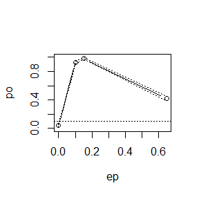

```r
library(MASS)
set.seed(19999)

u <- c(0,0)
d = 2
afa = 0.1
a = 30
b = 199
ep <- c(seq(0,0.15,0.1),seq(0.15,1,0.5))
L <- length(ep)
po <- numeric(L)
cr <- qchisq(0.9,d*(d+1)*(d+2)/6)
x <- matrix(0,a,d)

for(j in 1:L){
  q <- ep[j]
  s <- numeric(b)
  for(i in 1:b){
    σ <- sample(c(1,64), replace = T , size = a , prob = c(1-q , q) )
       for(g in 1:a){
         r <- matrix(c(σ[g],0,0,σ[g]),2,2)
         x[g,] <- mvrnorm(1, u, r)
       }
    s[i] <- as.integer(abs(Tl(x))>=cr)
  }
  po[j] <- mean(s)
}

plot(ep,po,type = "b" , xlab = bquote(ep) , ylim = c(0,1))
abline(h = 0.1, lty=3)
stanerror <- sqrt(po*(1-po)/b)
lines(ep,po+stanerror,lty=3)
lines(ep,po-stanerror,lty=3)
```

## Homework5

Exercises 7.7, 7.8, 7.9, and 7.B (pages 213, Statistical Computating with R).

**7.7**

Firstly, we calculate the sample estimate of $\theta$.

Secondly, we use bootstrap to estimate the bias and standard error of $\hat{\theta}$.

```r
data(scor,package="bootstrap")
m <- nrow(scor)
n <- ncol(scor)
x <- numeric(n)
for(i in 1:n){
  x[i] = mean(scor[,i])
}
y <- matrix(0,m,n)
for(i in 1:n){
  y[,i]=scor[,i]-x[i]
}
z <- t(y)%*%y/(m-1)

a <- eigen(z)$values
t = a[1]/sum(a)
t
```

```
## [1] 0.619115
```

```r
library(boot)
set.seed(10000)
f <- function(x,i){
  y <- x[i,]
  a <- eigen(cov(y))$values
  return(a[1]/sum(a))
}

bhat = boot(data = scor, statistic = f, R = 2000)
bis_bo = mean(bhat$t)-t
se_bo = sd(bhat$t)

bis_bo
```

```
## [1] 0.002651001
```

```r
se_bo
```

```
## [1] 0.04673587
```

So, we can get the sample estimate $\hat{\theta}$ is close to $0.62$. By using bootstrap $B=2000$, we can get the bis is close to $0.0027$, the standard error is close to $0.0467$.

**7.8**

```r
x <- numeric(m)
for(i in 1:m){
  y <- eigen(cov(scor[-i,]))$values
  x[i] <- y[1]/sum(y)
}
bis_ja = (m-1) * (mean(x)-t)
se_ja = (m-1) * sqrt(var(x)/m)

bis_ja
```

```
## [1] 0.001069139
```

```r
se_ja
```

```
## [1] 0.04955231
```

As we can see, by using Jackknife, we can get the bis is close to $0.0011$, the standard error is close to $0.0496$.

**7.9**

Compute $95\%$ percentile and BCa confidence intervals for $\hat{\theta}$.

```r
boot.ci(bhat, type = c("perc","bca"))
```

```
## BOOTSTRAP CONFIDENCE INTERVAL CALCULATIONS
## Based on 2000 bootstrap replicates
##
## CALL :
## boot.ci(boot.out = bhat, type = c("perc", "bca"))
##
## Intervals :
## Level     Percentile            BCa
## 95%   ( 0.5253,  0.7084 )   ( 0.5209,  0.7040 )
## Calculations and Intervals on Original Scale
```

As we can see, when I take $B=2000$, the $95\%$ percentile confidence intervals $(0.5253,0.7084)$ and the BCa confidence intervals $(0.5209,0.7040)$ for $\hat{\theta}$ are very close.

**7.B**

The skewness of the random variable $X$ is
$$\sqrt{\beta_1}=\frac{E[(X-\mu_X)]^3}{\sigma_X^3}$$
Where $\mu_X=E[X]$, $\sigma_X^2 = Var(X)$. And skewness statistics of samples is
$$\sqrt{b_1}=\frac{\frac{1}{n}\sum_{i=1}^n(x_i-\bar X)^3}{[\frac{1}{n}\sum_{i=1}^n(x_i-\bar X)^2]^{3/2}}$$
Firstly, we consider the normal distribution $N(0,1)$(skewness 0).

```r
library(boot)
set.seed(30000)

f <- function(x,i){
  y=x[i]
  ybar <- mean(y)
  p <- mean((y-ybar)^3)
  q <- mean((y-ybar)^2)
  return(p/(q^(3/2)))
}

a1 = b1 = c1 = 0
a2 = b2 = c2 = 0
a3 = b3 = c3 = 0

for(i in 1:10){
  x <- rnorm(10)
  y <- 0
  bhat = boot(data = x, statistic = f, R = 500)
  ci = boot.ci(bhat, type = c("norm","basic","perc"))
  if( y < ci$norm[2]){
    a1 = a1 + 1;
    c1 = c1 + 1;
  }
  if( y > ci$norm[3]){
    b1 = b1 + 1;
    c1 = c1 + 1;
  }
  if( y < ci$basic[4]){
    a2 = a2 + 1;
    c2 = c2 + 1;
  }
  if( y > ci$basic[5]){
    b2 = b2 + 1;
    c2 = c2 + 1;
  }
  if( y < ci$perc[4]){
    a3 = a3 + 1;
    c3 = c3 + 1;
  }
  if( y > ci$perc[5]){
    b3 = b3 + 1;
    c3 = c3 + 1;
  }
}

A <-c(1-c1/10,a1/10,b1/10)
B <-c(1-c2/10,a2/10,b2/10)
C <-c(1-c3/10,a3/10,b3/10)

Z <- rbind(A,B,C)
rownames(Z) <- c("norm","basic","perc")
colnames(Z) <- c("covskewneserage rate","left miss","right miss")
knitr::kable(head(Z))
```

|  | covskewneserage rate | left miss | right miss |
| --- | --- | --- | --- |
| norm | 0.9 | 0.1 | 0.0 |
| basic | 0.8 | 0.1 | 0.1 |
| perc | 1.0 | 0.0 | 0.0 |

Secondly, we consider $\chi ^2(5)$(positive skewness).

As we all know, the probability density function of $X \sim \chi ^2(5)$ is
$$f(x)=\frac{1}{3\sqrt{2\pi}}x^{\frac{3}{2}}e^{-\frac{x}{2}}$$
And $E(X)=5$, $Var(X)=10$, $E(X^2)=Var(X)+[E(X)]^2=35$.
$$E(X^3)=\int_{0}^{\infty}f(x)*x^3 \, dx \\
=\int_{0}^{\infty}\frac{1}{3\sqrt{2\pi}}x^{\frac{9}{2}}e^{-\frac{x}{2}} \, dx \\
=\frac{1}{3\sqrt{2\pi}}*2^{\frac{11}{2}}\int_{0}^{\infty}(\frac{x}{2})^{\frac{11}{2}-1}e^{-\frac{x}{2}} \, d(\frac{x}{2}) \\
=\frac{1}{3\sqrt{2\pi}}*2^{\frac{11}{2}}*\Gamma(\frac{11}{2}) \\
=315$$
So, the skewness of $\chi ^2(5)$ is
$$\sqrt{\beta_{\chi ^2(5)}}=\frac{E[(X-\mu_X)]^3}{\sigma_X^3} \\
=\frac{E(X^3)-3E(X)E(X^2)+2[E(X)]^3}{[Var(X)]^\frac{3}{2}} \\
=\frac{315-3*5*35+2*5^3}{10\sqrt{10}} \\
=\sqrt{\frac{8}{5}}$$

```r
library(boot)
set.seed(30000)

f <- function(x,i){
  y=x[i]
  ybar <- mean(y)
  p <- mean((y-ybar)^3)
  q <- mean((y-ybar)^2)
  return(p/(q^(3/2)))
}

a1 = b1 = c1 = 0
a2 = b2 = c2 = 0
a3 = b3 = c3 = 0

for(i in 1:10){
  x <- rchisq(10,5)
  y <-  sqrt(1.6)
  bhat = boot(data = x, statistic = f, R = 500)
  ci = boot.ci(bhat, type = c("norm","basic","perc"))
  if( y < ci$norm[2]){
    a1 = a1 + 1;
    c1 = c1 + 1;
  }
  if( y > ci$norm[3]){
    b1 = b1 + 1;
    c1 = c1 + 1;
  }
  if( y < ci$basic[4]){
    a2 = a2 + 1;
    c2 = c2 + 1;
  }
  if( y > ci$basic[5]){
    b2 = b2 + 1;
    c2 = c2 + 1;
  }
  if( y < ci$perc[4]){
    a3 = a3 + 1;
    c3 = c3 + 1;
  }
  if( y > ci$perc[5]){
    b3 = b3 + 1;
    c3 = c3 + 1;
  }
}

A <-c(1-c1/10,a1/10,b1/10)
B <-c(1-c2/10,a2/10,b2/10)
C <-c(1-c3/10,a3/10,b3/10)

Z <- rbind(A,B,C)
rownames(Z) <- c("norm","basic","perc")
colnames(Z) <- c("coverage rate","left miss","right miss")
knitr::kable(head(Z))
```

|  | coverage rate | left miss | right miss |
| --- | --- | --- | --- |
| norm | 0.9 | 0 | 0.1 |
| basic | 0.9 | 0 | 0.1 |
| perc | 0.8 | 0 | 0.2 |

## Homework6

Exercise 8.2 (page 242, Statistical Computating with R).

Design experiments for evaluating the performance of the NN, energy, and ball methods in various situations.

(1)Unequal variances and equal expectations

(2)Unequal variances and unequal expectations

(3)Non-normal distributions: t distribution with 1 df (heavy-tailed distribution), bimodel distribution (mixture of two normal distributions)

(4)Unbalanced samples (say, 1 case versus 10 controls).Note: The parameters should be chosen such that the powers are distinguishable (say, range from 0.3 to 0.8).

**8.2**

We take $\alpha = 0.05$.

Firstly, we choose
$$X_1 \sim N(0,1) \\ Y_1=X_1+1$$
Obviously, $X_1$ and $Y_1$ are not independent of each other. Then, test it.

```r
set.seed(12345)
library(boot)

xyCor <- function(Z,ix){
  x <- Z[,1]
  y <- Z[ix,2]
  return(cor(x,y,method = "spearman"))
}

X1 <- rnorm(15,0,1)
Y1 <- X1+1
Z1 <- cbind(X1,Y1)
a1 <- boot(data = Z1, statistic =xyCor, R=999, sim="permutation")
b1 <- c(a1$t0,a1$t)
mean(b1 >= a1$t0)
```

```
## [1] 0.001
```

```r
c1 <- cor.test(X1,Y1)
c1$p.value
```

```
## [1] 3.876914e-103
```

The achieved significance level of the permutation test is close to $0.001$. The p-value reported by cor.test on the same samples is $3.88*10^{-103}$. And we take $\alpha = 0.05$, so we can judge that $X_1$ and $Y_1$ are not independent.

Secondly,we choose
$$X_2 \sim N(0,1) \\ Y_2 \sim \chi^2(2)$$
Obviously, $X_2$ and $Y_2$ are independent of each other. Then, test it.

```r
X2 <- rnorm(15,0,1)
Y2 <- rchisq(15,2)
Z2 <- cbind(X2,Y2)
a2 <- boot(data = Z2, statistic =xyCor, R=999, sim="permutation")
b2 <- c(a2$t0,a2$t)
mean(b2 >= a2$t0)
```

```
## [1] 0.445
```

```r
c2 <- cor.test(X2,Y2)
c2$p.value
```

```
## [1] 0.860416
```

The achieved significance level of the permutation test is close to $0.445$. The p-value reported by cor.test on the same samples is $0.860$. And we take $\alpha = 0.05$, so we can judge that $X_2$ and $Y_2$ are independent.

**2.** We take $\alpha = 0.1$.

```r
set.seed(12345)
library(RANN)
library(boot)
library(energy)
library(Ball)

alpha=0.1;
N <- 100; k<-3; p<-2;B<-99;
L1 <- L2 <- 15; L <- L1+L2; LL = c(L1,L2)

NN <- function(X, ix, sizes,k) {
  L1 <- sizes[1]; L2 <- sizes[2]; L <- L1 + L2
  if(is.vector(X)) X <- data.frame(X,0);
  X <- X[ix, ];
  Y <- nn2(data=X, k=k+1)
  part1 <- Y$nn.idx[1:L1,-1]
  part2 <- Y$nn.idx[(L1+1):L,-1]
  i <- sum(part1 <= L1); j <- sum(part2 > L1)
  (i + j) / (k * L)
}

NNtest <- function(X,sizes,k){
  b <- boot(data=X,statistic=NN,R=B,sim = "permutation", sizes = sizes,k=k)
  T <- c(b$t0,b$t)
  pv <- mean(T>=T[1])
  list(statistic=T[1],p.value=pv)
}

p1 <- matrix(NA,N,3)
for(i in 1:N){
  A1 <- matrix(rnorm(L1*p),ncol=p);
  B1 <- cbind(rnorm(L2,0,2),rnorm(L2,0,2));
  C1 <- rbind(A1,B1)
  p1[i,1] <- NNtest(C1,LL,k)$p.value
  p1[i,2] <- eqdist.etest(C1,sizes=LL,R=B)$p.value
  p1[i,3] <- bd.test(x=A1,y=B1,num.permutations = B,seed=i*12345)$p.value
}
powercomparison1 <- colMeans(p1<alpha)

p2 <- matrix(NA,N,3)
for(i in 1:N){
  A2 <- cbind(rnorm(L1,0,2),rnorm(L1,0,2));
  B2 <- cbind(rnorm(L2,1.5,3),rnorm(L2,1.5,3));
  C2 <- rbind(A2,B2)
  p2[i,1] <- NNtest(C2,LL,k)$p.value
  p2[i,2] <- eqdist.etest(C2,sizes=LL,R=B)$p.value
  p2[i,3] <- bd.test(x=A2,y=B2,num.permutations = B,seed=i*12345)$p.value
}
powercomparison2 <- colMeans(p2<alpha)

p3 <- matrix(NA,N,3)
for(i in 1:N){
  A3 <- matrix(rt(L1*p,1),ncol=p);
  B3 <- cbind(rnorm(L2),rnorm(L2,1,1.5));
  C3 <- rbind(A3,B3)
  p3[i,1] <- NNtest(C3,LL,k)$p.value
  p3[i,2] <- eqdist.etest(C3,sizes=LL,R=B)$p.value
  p3[i,3] <- bd.test(x=A3,y=B3,num.permutations = B,seed=i*12345)$p.value
}
powercomparison3 <- colMeans(p3<alpha)

p4 <- matrix(NA,N,3)
L1<-10;L2<-100;L<-L1+L2;LL=c(L1,L2)
for(i in 1:N){
  A4 <- matrix(rnorm(L1*p),ncol=p);
  B4 <- matrix(rnorm(L2*p,1,2),ncol=p);
  C4 <- rbind(A4,B4)
  p4[i,1] <- NNtest(C4,LL,k)$p.value
  p4[i,2] <- eqdist.etest(C4,sizes=LL,R=B)$p.value
  p4[i,3] <- bd.test(x=A4,y=B4,num.permutations = B,seed=i*12345)$p.value
}
powercomparison4 <- colMeans(p4<alpha)
powercomparison <- rbind(powercomparison1,powercomparison2,powercomparison3,powercomparison4)
colnames(powercomparison) <- c('NN','Energy','Ball')
powercomparison
```

```
##                    NN Energy Ball
## powercomparison1 0.47   0.52 0.83
## powercomparison2 0.41   0.73 0.75
## powercomparison3 0.33   0.73 0.70
## powercomparison4 0.34   0.83 1.00
```

As you can see, different methods have different power in different situations. Ball method performs well in the above situation.

## Homework7

Exercise 9.3 and 9.8 (pages 277-278, Statistical Computating with R).

For each of the above exercise, use the Gelman-Rubin method to monitor convergence of the chain, and run the chain until it converges approximately to the target distribution according to $\hat R < 1.2$.

**9.3**

$-\infty <x< \infty$ in the Cauthy distribution, so we choose the proposal distribution is normal
$$g( \cdot |X_t) \sim N(X_t,\sigma^2) , -\infty <x< \infty$$

```r
set.seed(12345)

f <- function(theta,eta,x){
  stopifnot(theta > 0)
  return( 1/(theta*pi*(1+((x-eta)/theta)^2)) )
}

n <- 2000;
A <- numeric(n);
C <- runif(n);
A[1] <- rnorm(1,0,1);
i =0;
theta=1;eta=0;

for(j in 2:n){
  At <- A[j-1]
  B <- rnorm(1,At,1)
  H1 <- f(theta,eta,B)*dnorm(At,B,1)
  H2 <- f(theta,eta,At)*dnorm(B,At,1)
  if(C[j]<=H1/H2)
    A[j] = B
  else{
    A[j] = At
    i = i+1
  }
}

burnin <- 1001
X <- A[burnin:n]

q1 <- quantile(X,probs = seq(0.1,0.9,0.1))
q2 <- qt(seq(0.1,0.9,0.1),df=1)
Q <- rbind(q1,q2)
knitr::kable(head(Q))
```

|  | 10% | 20% | 30% | 40% | 50% | 60% | 70% | 80% | 90% |
| --- | --- | --- | --- | --- | --- | --- | --- | --- | --- |
| q1 | -1.610004 | -0.9447575 | -0.5407671 | -0.2531220 | -0.0236688 | 0.2240183 | 0.4875767 | 0.7889158 | 1.301216 |
| q2 | -3.077684 | -1.3763819 | -0.7265425 | -0.3249197 | 0.0000000 | 0.3249197 | 0.7265425 | 1.3763819 | 3.077684 |

**9.8**

We choose $a=1$, $b=1$, $n=10$, then use the Gibbs sampler to generate a chain with target joint density $f(x,y)$.

```r
set.seed(12345)
M <- 2*1e3
bi <- 1e3
A <- matrix(0,M,2)
a <- 1 ; b <- 1 ; n <- 10

A[1,] <- c(0,0)
for(i in 2:M){
  y <- A[i-1,2]
  A[i,1] <- rbinom(1,10,y)
  x <- A[i,1]
  A[i,2] <- rbeta(1,x+a,n-x+b)
}

X <- A[(bi+1):M,]
colMeans(X)
```

```
## [1] 5.2080000 0.5256165
```

```r
cov(X)
```

```
##            [,1]       [,2]
## [1,] 10.8255616 0.89847313
## [2,]  0.8984731 0.08827151
```

```r
cor(X)
```

```
##           [,1]      [,2]
## [1,] 1.0000000 0.9191144
## [2,] 0.9191144 1.0000000
```

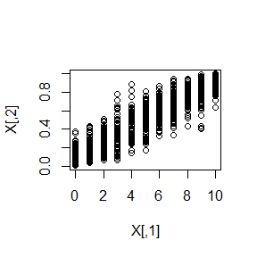

```r
plot(X,main = "")
```

From the final analysis of the chain, we can get some data properties.

**2.**

```r
GR <- function(fai){
  fai <- as.matrix(fai)
  n <- ncol(fai)
  k <- nrow(fai)

  faibar <- rowMeans(fai)
  Bn <- n*var(faibar)
  Wn <- mean(apply(fai, 1, "var"))
  return((Wn*(n-1)/n+(Bn/n))/Wn)
}
```

Firstly, we use the Gelman-Rubin method to monitor convergence of the chain in $9.3$.

```r
set.seed(12345)
n <- 2000;
m <- 4;

chain93 <- function(){
  A <- numeric(n);
  C <- runif(n);
  A[1] <- 20;
  i =0;
  theta=1;eta=0;

  for(j in 2:n){
    At <- A[j-1]
    B <- rnorm(1,At,1)
    H1 <- f(theta,eta,B)*dnorm(At,B,1)
    H2 <- f(theta,eta,At)*dnorm(B,At,1)
    if(C[j]<=H1/H2)
      A[j] = B
    else{
      A[j] = At
      i = i+1
    }
  }
  return(A)
}

Z <- matrix(0,m,n)
for(i in 1:m)
  Z[i,] <- chain93()

fai <- t(apply(Z,1,cumsum))
for(i in 1:nrow(fai))
  fai[i,] <- fai[i,]/(1:ncol(fai))
print(GR(fai))
```

```
## [1] 1.444076
```

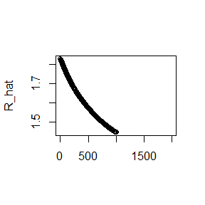

```r
b <- 1000;
rhat <- rep(0,n)
for(j in (b+1):n)
  rhat[j] <- GR(fai[,1:j])
plot(rhat[(b+1:n)], xlab="", ylab="R_hat")
abline(h=1.2)
```

As we can see, we haven’t get $\hat R<1.2$, so the chain in $9.3$ does not converge.

Secondly, we use the Gelman-Rubin method to monitor convergence of the chain in $9.8$.

```r
set.seed(12345)

M <- 2000;
m <- 4;

chain98 <- function(){
  A <- matrix(0,M,2)
  a <- 1 ; b <- 1 ; n <- 10
  A[1,] <- c(0,0)
  for(i in 2:M){
    y <- A[i-1,2]
    A[i,1] <- rbinom(1,10,y)
    x <- A[i,1]
    A[i,2] <- rbeta(1,x+a,n-x+b)
  }
  return(A)
}

Z1 <- matrix(0,m,M)
Z2 <- matrix(0,m,M)
for(i in 1:m){
  Q <- chain98()
  c <- Q[,1]
  d <- Q[,2]
  Z1[i,] <- c
  Z2[i,] <- d
}

fai1 <- t(apply(Z1,1,cumsum))
for(i in 1:nrow(fai1))
  fai1[i,] <- fai1[i,]/(1:ncol(fai1))
print(GR(fai1))
```

```
## [1] 1.729638
```

```r
fai2 <- t(apply(Z2,1,cumsum))
for(i in 1:nrow(fai2))
  fai2[i,] <- fai2[i,]/(1:ncol(fai2))
print(GR(fai2))
```

```
## [1] 1.792563
```

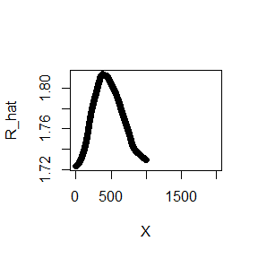

```r
b <- 1000;
Xrhat <- rep(0,M)
for(j in (b+1):M)
  Xrhat[j] <- GR(fai1[,1:j])
plot(Xrhat[(b+1:M)],xlab="X", ylab="R_hat")
abline(h=1.2)
```

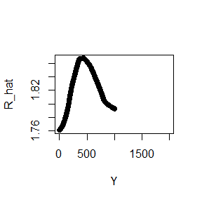

```r
Yrhat <- rep(0,M)
for(j in (b+1):M)
  Yrhat[j] <- GR(fai2[,1:j])
plot(Yrhat[(b+1:M)], xlab="Y", ylab="R_hat")
abline(h=1.2)
```

As we can see, we haven’t get $\hat R<1.2$, so the chain in $9.8$ does not converge, too.

## Homework8

Exercises 11.3 and 11.5 (pages 353-354, Statistical Computing with R)

Suppose $T_1,...,T_n$ are $i.i.d.$ samples drawn from the exponential distribution with expectation $\lambda$. Those values greater than $\tau$ are not observed due to right censorship, so that the observed values are $Y_i = T_iI(T_i \le \tau)+\tau I(T_i > \tau)$,$i = 1,...,n$. Suppose $\tau = 1$ and the observed $Y_i$ values are as follows:
$$0.54, 0.48, 0.33, 0.43, 1.00, 1.00, 0.91, 1.00, 0.21, 0.85$$
Use the E-M algorithm to estimate $\lambda$, compare your result with the observed data MLE (note: $Y_i$ follows a mixture distribution)

**11.3**

**(a)** As required, we need to compute
$$Y_k = \frac{(-1)^k}{k!2^k}\frac{{||a||^{2k+2}}}{(2k+1)(2k+2)}\frac{\Gamma(\frac{d+1}{2})\Gamma(k+\frac{3}{2})}{\Gamma(k+\frac{d}{2}+1)}$$

```r
Yk <- function(k,a){
  yk1 = (-1)^k/factorial(k)/(2^k)
  d = length(a)
  ena = 0
  for(i in 1:d){
    ena <- ena + a[i]^2
  }
  ena <- sqrt(ena)

  yk2 = (ena^(2*k+2))/((2*k+1)*(2*k+2))
  yk3 = exp(lgamma((d+1)/2)+lgamma(k+1.5)-lgamma(k+d/2+1))
  return(yk1 * yk2 * yk3)
}
```

**(b)** Then, we need to compute
$$\sum_{k=0}^{\infty}Y_k$$

```r
SumofYk <- function(a){
  i=0; sumofyk=0;
  while (abs(Yk(i,a)) > 0.00000001) {
      sumofyk=sumofyk + Yk(i, a);
      i=i+1;
  }
  return(sumofyk)
}
```

**(c)**

```r
a <- c(1,2)
SumofYk(a)
```

```
## [1] 1.532164
```

As we can see, the sum of $a = {(1,2)}^T$ is $1.532164$.

**11.5**

If we make $X_{k-1}$ equal to the left side of the equation, we need to solve the equation
$$X_{k-1} = X_k$$
As we all know, the probability density function of $t(n)$ is
$$f(x)=\frac{\Gamma(\frac{n+1}{2})}{\sqrt{n\pi}\Gamma(\frac{n}{2})}(1+\frac{x^2}{n})^{-\frac{n+1}{2}}$$
And the probability density function of $t(n)$ is symmetric about the y-axis. So,
$$X_{k-1} = X_k$$
is equivalent to
$$S_{k-1} = S_k$$
Where $S_k$ has been defined in $11.4$.

```r
aoff <- function(k){
  x <- uniroot( function(a) {pt(sqrt((a^2)*(k-1)/(k-a^2)),df=k-1)-pt(sqrt((a^2)*k/(k+1-a^2)),df=k)}
                ,c(0.00002, sqrt(k)-0.00002))$root
  return(x)
}

N <- c(4:25,100,500,1000)
L <- length(N)
X <- numeric(L)
for(j in 1:L){
  X[j]=aoff(N[j])
}

Y <- cbind(N,X)
colnames(Y) = c("k","a")
Y
```

```
##          k         a
##  [1,]    4  1.492103
##  [2,]    5  1.533549
##  [3,]    6  1.562768
##  [4,]    7  1.584421
##  [5,]    8  1.601182
##  [6,]    9  1.614541
##  [7,]   10  1.625383
##  [8,]   11  1.634409
##  [9,]   12  1.642033
## [10,]   13  1.648539
## [11,]   14  1.654192
## [12,]   15  1.659098
## [13,]   16  1.663452
## [14,]   17  1.667288
## [15,]   18  1.670736
## [16,]   19  1.673841
## [17,]   20  1.676588
## [18,]   21  1.679139
## [19,]   22  1.681461
## [20,]   23  4.795812
## [21,]   24  4.898959
## [22,]   25  4.999980
## [23,]  100  9.999980
## [24,]  500 22.360660
## [25,] 1000 31.622757
```

**2.**

The probability density function of $Exp(\lambda)$ is
$$f(y)=\lambda e^{-\lambda y}, y>0$$
And we can get
$$\int_{1}^{\infty}\lambda e^{-\lambda y}\,dy=e^{-\lambda}$$
As we can see, $7$ of the observed $Y_i$ values less than $1$. We call it $y_i,i=1,..,7$.

Firstly, we consider the $MLE$ of the observed data.
$$L(Y;\lambda)=C_{10}^3*(e^{-\lambda})^3 \prod_{i=1}^{7}(\lambda e^{-\lambda y_i})$$
$$logL(Y;\lambda)=log(C_{10}^3)-3\lambda+7log\lambda-\lambda\sum_{i=1}^{7}y_i$$
After the derivation, we can get
$$\hat \lambda=\frac{7}{\sum_{i=1}^{7}y_i+3}=\frac{28}{27} \approx 1.037037$$

Secondly, use the E-M algorithm to estimate $\lambda$.

(1)Initiate $\lambda$ with $\lambda _0$.

(2)Complete data likelihood:
$$L(\lambda;Y)=\prod_{i=1}^{10}(\lambda e^{-\lambda y_i})$$
$$logL(\lambda;Y)=10log\lambda-\lambda\sum_{i=1}^{10}y_i$$

(3)E-step:
$$I_0=E_{\lambda _0}[logL|Y]=10log\lambda-\lambda\sum_{i=1}^{k}y_i-\lambda\sum_{i=k+1}^{10}(\int_1^{\infty}y_ie^{-\lambda_0(x-1)}\,dy_i)$$
$$I_0=10log\lambda-\lambda\sum_{i=1}^{k}y_i-\lambda(10-k)(\frac{1}{\lambda_o}+1)$$

(4)M-step:
$$maxI_0$$
We can get
$$\lambda_1=\frac{10}{\sum_{i=1}^{k}y_i+(10-k)(\frac{1}{\lambda_o}+1)}$$

```r
x <- c(0.54, 0.48, 0.33, 0.43, 1.00, 1.00, 0.91, 1.00, 0.21, 0.85)
A <- 3
B <- 10/(sum(x)+3/A)

while (abs(B-A)>0.000000000001){
  A <- B
  B <- 10/(sum(x)+3/A)
}
B
```

```
## [1] 1.037037
```

As we can see, the results of E-M and the observed data MLE are the same.

## Homework9

Exercises 1 and 5 (page 204, Advanced R).Excecises 1 and 7 (page 214, Advanced R)

**P204 1**

$trims <- c(0, 0.1, 0.2, 0.5)$

$x <- rcauchy(100)$

$lapply(trims, function(trim) mean(x, trim = trim))$

$lapply(trims, mean, x = x)$

Because both of the two invocations of lapply() mean: after arranging vector $x$ in order, cut off $0\%,10\%,20\%,50\%$ of the Outliers at the beginning and end, and find the mean value of the remaining numbers.

And the first parameter of the $mean()$ can be provided by the third parameter of $lapply()$, so the following two invocations of lapply() are equivalent.

**P204 5**

As for Exercise 3:

```r
attach(mtcars)

formulas <- list(
mpg ~ disp,
mpg ~ I(1 / disp),
mpg ~ disp + wt,
mpg ~ I(1 / disp) + wt
)

n1 <- length(formulas)
A1 <- vector("list",n1)
for(j in seq_along(formulas)){
  A1[[j]] <- lm(formulas[[j]])
}

A2 <- lapply(formulas, lm)
rsq <- function(mod) summary(mod)$r.squared

lapply(A1, rsq)
```

```
## [[1]]
## [1] 0.7183433
##
## [[2]]
## [1] 0.8596865
##
## [[3]]
## [1] 0.7809306
##
## [[4]]
## [1] 0.8838038
```

```r
lapply(A2, rsq)
```

```
## [[1]]
## [1] 0.7183433
##
## [[2]]
## [1] 0.8596865
##
## [[3]]
## [1] 0.7809306
##
## [[4]]
## [1] 0.8838038
```

As for Exercise 4:

```r
bootstraps <- lapply(1:10, function(i) {
  rows <- sample(1:nrow(mtcars), rep = TRUE)
  mtcars[rows, ]
})

n2 <- length(bootstraps)
B1 <- vector("list",length(bootstraps))
for(j in seq_along(bootstraps)){
  B1[[j]] <- lm(mpg ~ disp, bootstraps[[j]])
}

B2 <- lapply(bootstraps, lm, formula = mpg ~ disp)
rsq <- function(mod) summary(mod)$r.squared

lapply(B1, rsq)
```

```
## [[1]]
## [1] 0.6157021
##
## [[2]]
## [1] 0.7426137
##
## [[3]]
## [1] 0.7090495
##
## [[4]]
## [1] 0.5515627
##
## [[5]]
## [1] 0.7422951
##
## [[6]]
## [1] 0.7390564
##
## [[7]]
## [1] 0.7944183
##
## [[8]]
## [1] 0.7864715
##
## [[9]]
## [1] 0.8016978
##
## [[10]]
## [1] 0.6228064
```

```r
lapply(B2, rsq)
```

```
## [[1]]
## [1] 0.6157021
##
## [[2]]
## [1] 0.7426137
##
## [[3]]
## [1] 0.7090495
##
## [[4]]
## [1] 0.5515627
##
## [[5]]
## [1] 0.7422951
##
## [[6]]
## [1] 0.7390564
##
## [[7]]
## [1] 0.7944183
##
## [[8]]
## [1] 0.7864715
##
## [[9]]
## [1] 0.8016978
##
## [[10]]
## [1] 0.6228064
```

**P214 1**

**a**To compute the standard deviation of every column in a numeric data frame. Assume $A$ is a numeric data frame. Then, we can use
$$vapply(A,sd,numric(1))$$
**b**To compute the standard deviation of every numeric column in a mixed data frame. Assume $B$ is a mixed data frame. Then, we can use
$$vapply(B[vapply(B, is.numeric, logical(1))],sd,numeric(1))$$

**P214 7**

Firstly, What is vapply? $vapply(X,FUN,FUN.VALUE,…,USE.NAMES=TRUE)$ similar to sapply, but has a pre-specified type of return value, so it can be safer (and sometimes faster) to use.

Secondly, what is sapply? $sapply(X,FUN,…,simplify=TRUE,USE.NAMES=TRUE)$ a user-friendly version and wrapper of lapply by default returning a vector, matrix or, if simplify = “array”, an array if appropriate, by applying $simplify2array()$. $sapply(x, f, simplify = FALSE, USE.NAMES = FALSE)$ is the same as $lapply(x, f)$.

And $mcsapply()$ is a multicore version of $sapply()$.I can’t implement a $mcvapply()$.

## Homework10

(1)Write an Rcpp function for Exercise 9.8 (page 278, StatisticalComputing with R).

(2)Compare the corresponding generated random numbers with pure R language using the function “qqplot”.

(3)Compare the computation time of the two functions with the function “microbenchmark”.

(4)Comments your results.

**1.** pure R language:

```r
pureR <- function(a,b,n,M){
  A <- matrix(0,M,2)
  A[1,] <- c(0,0)
  for(j in 2:M){
    y <- A[j-1,2]
    A[j,1] <- rbinom(1,10,y)
    x <- A[j,1]
    A[j,2] <- rbeta(1,x+a,n-x+b)
  }
  return(A)
}
```

Rcpp function:

```r
library(Rcpp)
cppFunction('NumericMatrix CppFun(double a, double b, int n, int M) {
            NumericMatrix A(M,2);
            A(0, 0) = A(0, 1) = 0;
            double x; double y;
            for(int j = 1; j < M; j++)
            {
              y = A(j-1, 1);
              A(j, 0) = rbinom(1, n, y)[0];
              x = A(j, 0);
              A(j, 1) = rbeta(1, x+a, n-x+b)[0];
            }
            return A;
}')
```

**2.**

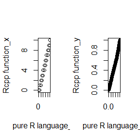

```r
set.seed(12345)
library(Rcpp)
library(microbenchmark)
a <- 1; b <- 1; n <- 10; M <- 5*1e3;

Z1 <- pureR(1,1,10,5*1e3)
Z2 <- CppFun(1,1,10,5*1e3)

par(mfrow = c(1, 2))
qqplot(Z1[1001:M,1],Z2[1001:M,1],xlab='pure R language_x',ylab='Rcpp function_x')
qqplot(Z1[1001:M,2],Z2[1001:M,2],xlab='pure R language_y',ylab='Rcpp function_y')
```

**3.**

```r
library(microbenchmark)
timecompare <- microbenchmark(R=pureR(1,1,10,5*1e3),Rcpp=CppFun(1,1,10,5*1e3))
print(summary(timecompare)[, c(1,3,5,6)])
```

```
##   expr       lq   median       uq
## 1    R 15.66685 20.57125 21.07555
## 2 Rcpp  1.62275  1.63025  1.64410
```

**4.** As we can see, the computation time of the Rcpp function is much less than pure R language. So the Rcpp function is more efficient.